# Report 1

Daniel J. Naumenko

8 February 2022

## Report Introduction

Rebecca Brittain and Caitlin O’Connell have increased the size of the oxidative stress and inflammation biomarker samples, and cleaned nutritional data are primarily available. Therefore, I am creating a new first report to detail the exploratory data analysis and eventual hypothesis testing for the caloric and dietary restriction and aging paper.

I have made the CRediT Taxonomy of Author Contributions into a table, which is presented in it’s preliminary form below. I have gone through and identified where I think people belong based on memory (note that I will not forget middle initials when it comes time for publication). Please let me know if the author list should change, and if specific contributions should be added or removed. This is open and subject to change, pending discussion among authors. As of now, the key points for inclusion are that: Rebecca, Caitlin, and Erin have done lab work after I left the lab, and Tim is included in this if cortisol is used; Tim and Rebecca worked on nutritional calculations; Suci and Erin supervised/managed the field site, the lab, etc; and I conceptualized the projects revolving around oxidative stress and aging in orangutans, dietary restriction, etc. Blank spaces have yet to be filled in.

As of now, I think I was the only one to conceive of the caloric restriction project in its form, given I introduced the biomarkers into the lab and explored caloric restriction as having a causal role in lifespan and orangutan health.

| CRediT Taxonomy Category | Description | Daniel J. Naumenko | Rebecca S.A. Brittain | Caitlin A. O’Connell | Timothy D. Bransford | Sri Suci Utami Atmoko | Erin R. Vogel |
| --- | --- | --- | --- | --- | --- | --- | --- |
| Conceptualization | Ideas; formulation or evolution of overarching research goals and aims. | Yes | No | No | No | No | No |
| Data Curation | Management activities to annotate (produce metadata), scrub data and maintain research data (including software code, where it is necessary for interpreting the data itself) for initial use and later … | Yes | Yes | No | Yes | No | No |
| Formal Analysis | Application of statistical, mathematical, computational, or other formal techniques to analyze or synthesize study data. | Yes | No | No | No | No | No |
| Funding Acquisition | Acquisition of the financial support for the project leading to this publication. | Yes | No | No | No |  | Yes |
| Investigation | Conducting a research and investigation process, specifically performing the experiments, or data/evidence collection. | Yes | Yes | Yes | Yes | No | Yes |
| Methodology | Development or design of methodology; creation of models. | Yes | No | No | No | No | No |
| Project Administration | Management and coordination responsibility for the research activity planning and execution. | Yes |  | No |  | Yes | Yes |
| Resources | Provision of study materials, reagents, materials, patients, laboratory samples, animals, instrumentation, computing resources, or other analysis tools. | No | No | No | No | No | Yes |
| Software | Programming, software development; designing computer programs; implementation of the computer code and supporting algorithms; testing of existing code components. | NA | NA | NA | NA | NA | NA |
| Supervision | Oversight and leadership responsibility for the research activity planning and execution, including mentorship external to the core team. | Yes |  |  |  | Yes | Yes |
| Validation | Verification, whether as a part of the activity or separate, of the overall replication/reproducibility of results/experiments and other research outputs. | Yes | No | No | No | No | Yes |
| Visualization | Preparation, creation and/or presentation of the published work, specifically visualization/data presentation. | Yes |  |  |  |  |  |
| Writing - Original Draft | Preparation, creation and/or presentation of the published work, specifically writing the initial draft (including substantive translation). | Yes |  |  |  |  |  |
| Writing - Review and Editing | Preparation, creation and/or presentation of the published work by those from the original research group, specifically critical review, commentary or revision, including pre- or post-publication stag… |  |  |  |  |  |  |

Note:  
For more information: https://casrai.org/credit/

## Exploratory Data Analysis

All 4 biomarkers have been screened for outliers and other exclusionary factors. This first pass INCLUDES non-first-morning voids. It will be repeated with those removed to see if results significantly change. As this is a first pass prior to the remainder of samples being run, I decided to include everything for now. Samples with a CV > 15% were removed. Samples with a specific gravity <= 1.003 were also removed as being too dilute. Finally, for each biomarker, those observations which exceeded +3SD or -3SD were also removed. I am debating on whether this step is appropriate. It may be relevant to include for 8-OHdG, TAC, or neopterin, but I think the outlier procedure should remain in place for cortisol. This biomarker has some extreme values that will almost certainly impact data analysis. See distributions below under Variation.

### Variation

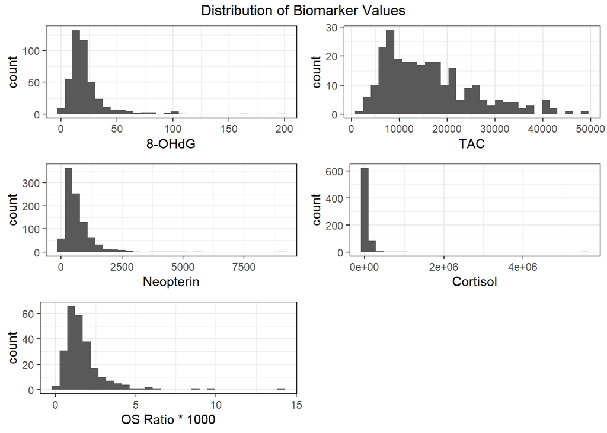

Unsurprisingly, all biomarkers are right-skewed. Even with outliers removed following the protocol described above, cortisol’s distribution is the most extreme, with a poor spread of extremely high values. Compare this with 8-OHdG and neopterin which also have several high values but a more representative spread of those high values. Also of note, TAC has a much wider and more evenly spread distribution of values relative to 8-OHdG. The purpose of the OS Ratio (which is 8-OHdG / TAC * 1000) is to help capture the relative impact of each biomarker. Oxidative stress is the inability for TAC to stop oxidative damage, meaning that levels of 8-OHdG must be interpreted in light of TAC values. A low 8-OHdG value with a high TAC value indicates that something is increasing oxidative stress but that antioxidant defenses are currently sufficient to handle the issue. If both values are high, then the antioxidant defense are responding but being overwhelmed.

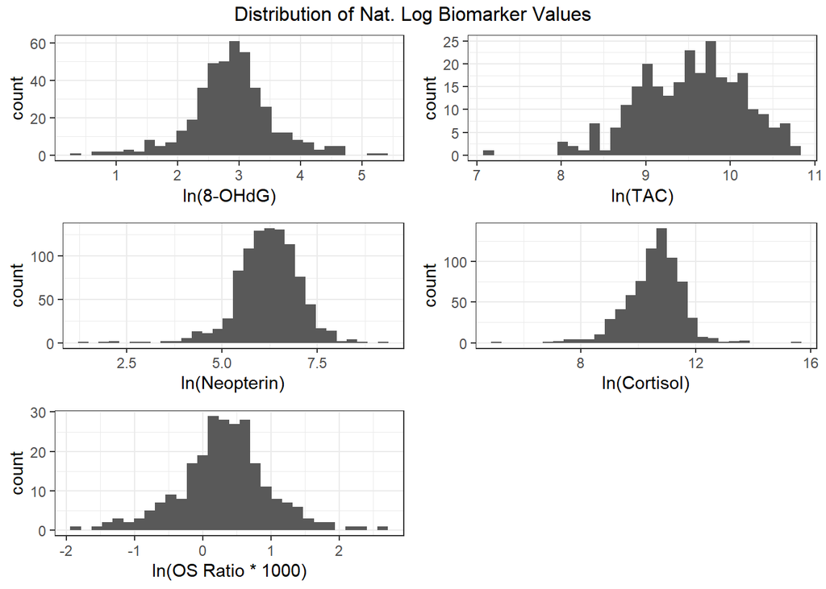

Descriptive Statistics: 8-OHdG

| age_class_simp | n_obs | mean | median | mode_whole | sd | minimum | maximum | IQR | Q1 | Q3 |
| --- | --- | --- | --- | --- | --- | --- | --- | --- | --- | --- |
| Adult Female | 225 | 24.15768 | 17.60400 | 15 | 24.097835 | 1.347310 | 198.42000 | 11.833527 | 12.93120 | 24.76473 |
| Adult Male | 180 | 21.51579 | 18.90889 | 23 | 14.217700 | 1.860571 | 81.84291 | 14.684073 | 12.26069 | 26.94476 |
| Inf-Juv | 26 | 15.72681 | 13.93443 | 11 | 6.291791 | 6.540000 | 28.94182 | 9.574097 | 10.63643 | 20.21053 |

Descriptive Statistiscs: Total Antioxidant Capacity (TAC)

| age_class_simp | # of Observations | mean | median | mode_whole | sd | minimum | maximum | IQR | Q1 | Q3 |
| --- | --- | --- | --- | --- | --- | --- | --- | --- | --- | --- |
| Adult Female | 141 | 16421.31 | 14982.928 | 12461 | 8868.500 | 1280.565 | 41910.11 | 11629.162 | 9494.688 | 21123.85 |
| Adult Male | 105 | 16943.20 | 14430.983 | 6176 | 10420.008 | 2881.975 | 48385.66 | 15929.521 | 7946.070 | 23875.59 |
| Inf-Juv | 16 | 11220.95 | 9479.229 | 17309 | 5383.736 | 3362.304 | 20987.28 | 7190.426 | 7342.060 | 14532.49 |

Descriptive Statistiscs: Oxidative Stress Ratio (x1000)

| age_class_simp | # of Observations | mean | median | mode_whole | sd | minimum | maximum | IQR | Q1 | Q3 |
| --- | --- | --- | --- | --- | --- | --- | --- | --- | --- | --- |
| Adult Female | 134 | 1.735826 | 1.301932 | 1 | 1.7702363 | 0.1584740 | 14.215600 | 0.9775664 | 0.9142283 | 1.891795 |
| Adult Male | 99 | 1.701756 | 1.485866 | 1 | 1.0501129 | 0.2354285 | 6.075596 | 1.0570266 | 0.9990829 | 2.056109 |
| Inf-Juv | 15 | 1.844847 | 1.759819 | 2 | 0.9621119 | 0.6085636 | 4.156674 | 1.1587238 | 1.1183861 | 2.277110 |

The mode for this table is not very interpretable. To calculate mode, I rounded to whole numbers for consistency. It is entirely unsurprising that 1 is the mode for both adult males and females, as it is the center of a very tiny range.

Descriptive Statistics: Neopterin

| age_class_simp | # of Observations | mean | median | mode_whole | sd | minimum | maximum | IQR | Q1 | Q3 |
| --- | --- | --- | --- | --- | --- | --- | --- | --- | --- | --- |
| Adult Female | 426 | 663.4192 | 472.1419 | 319 | 758.0623 | 8.226857 | 9052.794 | 517.5455 | 291.5439 | 809.0893 |
| Adult Male | 448 | 689.6226 | 541.1799 | 425 | 499.1704 | 3.456545 | 3009.104 | 514.7734 | 362.2015 | 876.9750 |
| Inf-Juv | 66 | 656.6710 | 535.0237 | 365 | 569.2687 | 64.670400 | 4063.038 | 423.7718 | 334.4458 | 758.2176 |

Descriptive Statistics: Cortisol

| age_class_simp | # of Observations | mean | median | mode_whole | sd | minimum | maximum | IQR | Q1 | Q3 |
| --- | --- | --- | --- | --- | --- | --- | --- | --- | --- | --- |
| Adult Female | 348 | 63907.04 | 37152.68 | 45290 | 299910.04 | 160.5823 | 5564881.3 | 40931.71 | 19871.78 | 60803.49 |
| Adult Male | 320 | 72066.97 | 52304.94 | 54195 | 106916.94 | 1055.6400 | 1039548.0 | 54418.78 | 30265.39 | 84684.17 |
| Inf-Juv | 51 | 41828.75 | 31154.93 | 209544 | 37777.26 | 7996.5273 | 209544.2 | 28680.52 | 17938.63 | 46619.15 |

### Covariation

I should note that it might be valuable to look at creatinine corrections because all available literature corrects urinary 8-OHdG with creatinine. The only difference was Nicole Thompson-Gonzalez’s study out of Melissa Emery Thompson’s lab. However, she did not provide any descriptive statistics, only model outputs. Therefore I do not know what sort of range her data had (which is rather frustrating). They included some plots, but ….*sigh*. It looks like, for 8-OHdG, the median for before, during, and after their so called epidemic is 8, 10, and 12 ng/mL, with almost all points falling below 20 ng/mL. They put in a few other graphs. However, they did not adjust oxidative damage for antioxidant capacity at all, despite also measuring TAC. I have included Supplementary Tables 5 and 6 from this publication below.

Now curiously, she found no correlation between 8-OHdG and TAC. If you see the correlation plot below the two tables, there is a reasonably strong spearman correlation between 8-OHdG and TAC in our data. From just a spearman, there is no correlation between 8-OHdG and neopterin. These are, of course, raw biomarkers

Table S5: Correlations between OS biomarkers

| Biomarker 1 | Biomarker 2 | n_individual | n_samles | rho | p-value |
| --- | --- | --- | --- | --- | --- |
| **8-OHdG** |  |  |  |  |  |
| 8-OHdG | Isop | 26 | 336 | 0.29 | <0.001 |
| 8-OHdG | MDA-TBARS | 33 | 484 | 0.10 | 0.03 |
| 8-OHdG | Neo | 37 | 631 | 0.09 | 0.03 |
| 8-OHdG | TAC | 32 | 470 | -0.05 | 0.3 |
| **Isop** |  |  |  |  |  |
| Isop | MDA-TBARS | 26 | 291 | 0.12 | 0.047 |
| Isop | Neo | 26 | 300 | 0.07 | 0.23 |
| Isop | TAC | 26 | 327 | 0.49 | <0.001 |
| **MDA-TBARS** |  |  |  |  |  |
| MDA-TBARS | Neo | 33 | 381 | 0.06 | 0.27 |
| MDA-TBARS | TAC | 26 | 288 | 0.00 | 0.98 |
| **Neo** |  |  |  |  |  |
| Neo | TAC | 32 | 441 | 0.13 | 0.01 |

Table S6: Cross-sectional variation in OS biomarker by individual age and sex

| Biomarker | n_individuals | n_samples | predictor | beta | SE | CI_95 | p | percentRE |
| --- | --- | --- | --- | --- | --- | --- | --- | --- |
| **8-OHdG** |  |  |  |  |  |  |  |  |
| 8-OHdG | 36 | 582 | Intercept | 2.82 | 0.06 | 2.71 - 2.94 | < 0.001 | 6.92 |
| 8-OHdG | 36 | 582 | sex (M) | -0.07 | 0.08 | -0.32 | 0.401 | 6.92 |
| 8-OHdG | 36 | 582 | age | -0.10 | 0.05 | -0.18 | 0.028 | 6.92 |
| **Isoprostanes** |  |  |  |  |  |  |  |  |
| Isoprostanes | 23 | 182 | Intercept | 1.34 | 0.13 | 1.08 - 1.6 | < 0.001 | 18.46 |
| Isoprostanes | 23 | 182 | sex (M) | -0.05 | 0.19 | -0.76 | 0.793 | 18.46 |
| Isoprostanes | 23 | 182 | age | 0.05 | 0.10 | -0.38 | 0.606 | 18.46 |
| **MDA-TBARS** |  |  |  |  |  |  |  |  |
| MDA-TBARS | 31 | 249 | Intercept | 2.59 | 0.07 | 2.45 - 2.72 | < 0.001 | 6.53 |
| MDA-TBARS | 31 | 249 | sex (M) | -0.04 | 0.09 | -0.35 | 0.692 | 6.53 |
| MDA-TBARS | 31 | 249 | age | -0.01 | 0.04 | -0.16 | 0.829 | 6.53 |
| **Neopterin** |  |  |  |  |  |  |  |  |
| Neopterin | 36 | 409 | Intercept | 6.97 | 0.06 | 6.84 - 7.09 | < 0.001 | 8.00 |
| Neopterin | 36 | 409 | sex (M) | 0.05 | 0.09 | -0.36 | 0.562 | 8.00 |
| Neopterin | 36 | 409 | age | -0.01 | 0.05 | -0.18 | 0.831 | 8.00 |
| **TAC** |  |  |  |  |  |  |  |  |
| TAC | 31 | 295 | Intercept | 0.10 | 0.31 | -1.2 | 0.741 | 14.97 |
| TAC | 31 | 295 | sex (M) | -0.32 | 0.47 | -1.84 | 0.504 | 14.97 |
| TAC | 31 | 295 | age | -0.02 | 0.24 | -0.92 | 0.927 | NA |

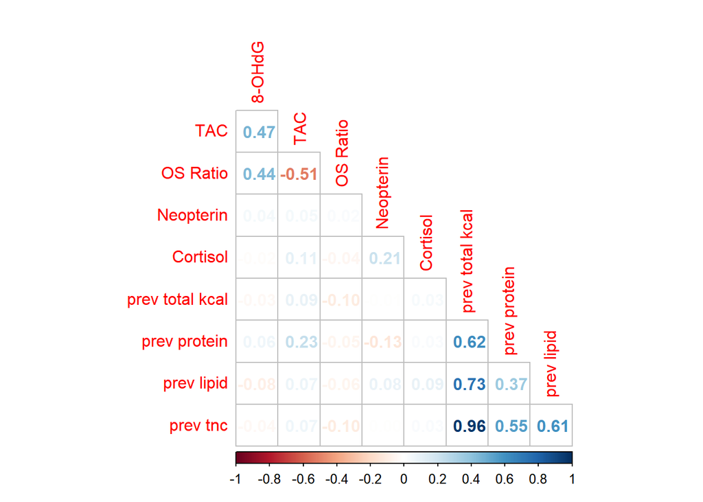

These correlations here are from Tuanan data, while the two tables above are from Nicole’s paper on chimps.

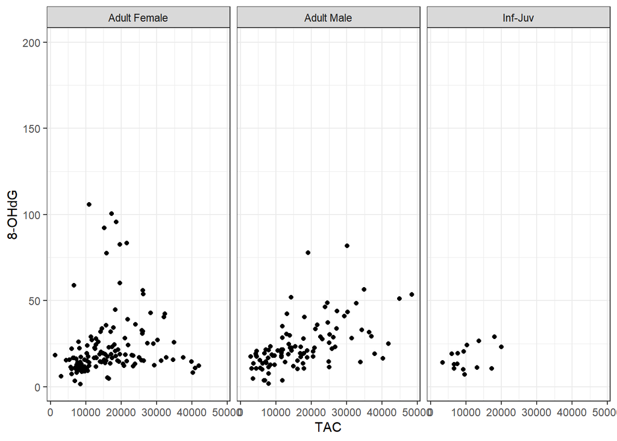

The direction of relationships seems to be the same, roughly speaking, across all 3 age-sex classes.

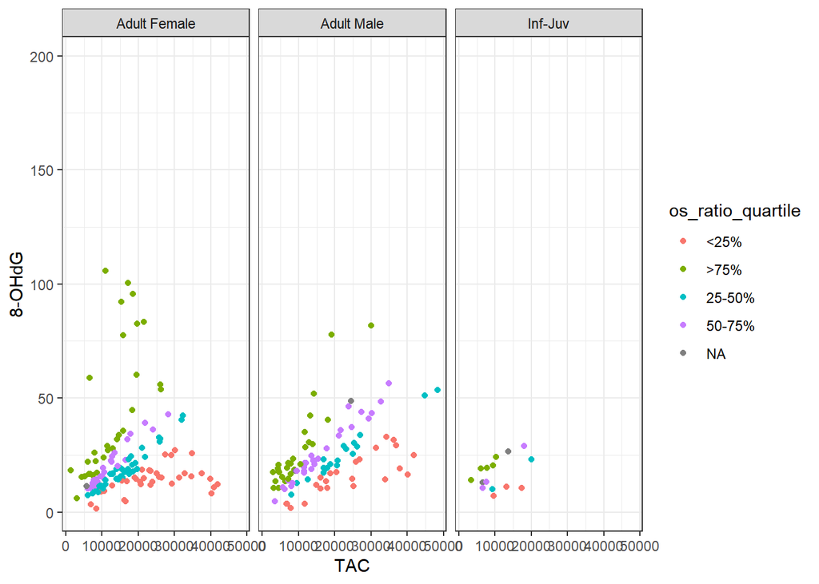

### Caloric Restriction and Oxidative Stress

I need to make sure the list of orangutan IDs is correct, as well as double check that age-sex classes are input properly.

```
##
## Family: gaussian
## Link function: identity
##
## Formula:
## ohdg_keep ~ s(tac_keep_umol)
##
## Parametric coefficients:
##             Estimate Std. Error t value Pr(>|t|)
## (Intercept)   23.063      1.118   20.62   <2e-16 ***
## ---
## Signif. codes:  0 '***' 0.001 '**' 0.01 '*' 0.05 '.' 0.1 ' ' 1
##
## Approximate significance of smooth terms:
##                    edf Ref.df     F  p-value
## s(tac_keep_umol) 2.412  2.412 15.01 5.52e-07 ***
## ---
## Signif. codes:  0 '***' 0.001 '**' 0.01 '*' 0.05 '.' 0.1 ' ' 1
##
## R-sq.(adj) =  0.132
##   Scale est. = 242.22    n = 248
```

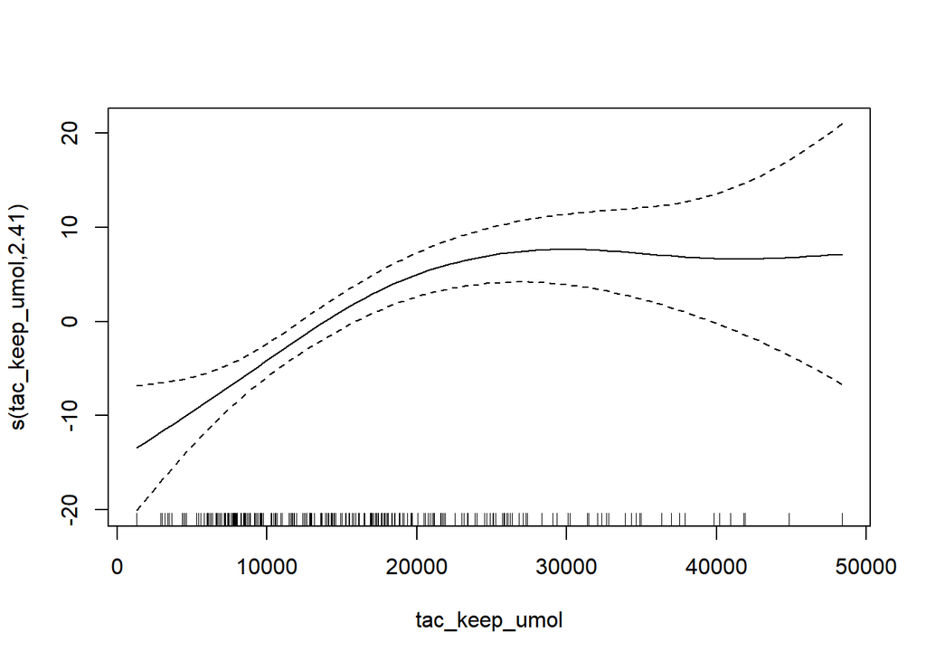

So the two biomarkers increase with each other. The way I am thinking of this is antioxidant defenses are increasing in response to free radicals, but not necessarily dealing with all them, thus resulting in damage. At the upper end of TAC, two things could be happening…1) there is just insufficient samples. The rug plot seems to show a spread of data so I’m not sure this is necessarily the case. The second option is that so many antioxidants are being produced that free radicals are being dealt with. Another option is that there is a large influx of dietary antioxidants that have nothing to do with free radicals, or that antioxidants are increasing for some other reason.

Make sure to assess the fit.

```
##
## Family: gaussian
## Link function: identity
##
## Formula:
## ohdg_keep ~ s(prev_day_total_kcal_using_ap_low_fermentation)
##
## Parametric coefficients:
##             Estimate Std. Error t value Pr(>|t|)
## (Intercept)   22.595      1.427   15.84   <2e-16 ***
## ---
## Signif. codes:  0 '***' 0.001 '**' 0.01 '*' 0.05 '.' 0.1 ' ' 1
##
## Approximate significance of smooth terms:
##                                                  edf Ref.df     F p-value
## s(prev_day_total_kcal_using_ap_low_fermentation)   1      1 2.647   0.105
##
## R-sq.(adj) =  0.00661
##   Scale est. = 384.79    n = 263
```

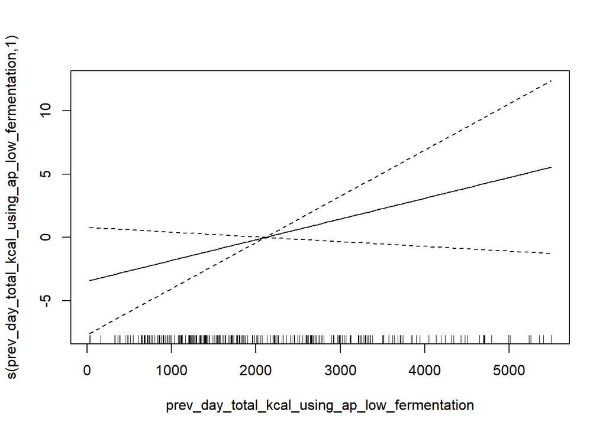

```
##
## Family: gaussian
## Link function: identity
##
## Formula:
## tac_keep_umol ~ s(prev_day_total_kcal_using_ap_low_fermentation)
##
## Parametric coefficients:
##             Estimate Std. Error t value Pr(>|t|)
## (Intercept)    16686       1116   14.95   <2e-16 ***
## ---
## Signif. codes:  0 '***' 0.001 '**' 0.01 '*' 0.05 '.' 0.1 ' ' 1
##
## Approximate significance of smooth terms:
##                                                  edf Ref.df     F p-value
## s(prev_day_total_kcal_using_ap_low_fermentation)   1      1 3.862   0.051 .
## ---
## Signif. codes:  0 '***' 0.001 '**' 0.01 '*' 0.05 '.' 0.1 ' ' 1
##
## R-sq.(adj) =  -0.00755
##   Scale est. = 7.2786e+07  n = 177
```

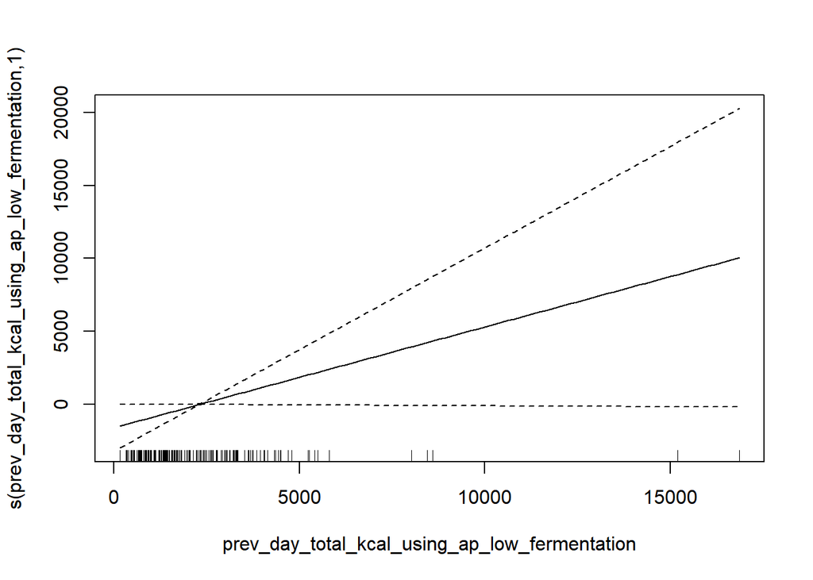

```
##
## Family: gaussian
## Link function: identity
##
## Formula:
## ohdg_keep ~ s(prev_day_total_kcal_using_ap_low_fermentation) +
##     s(tac_keep_umol)
##
## Parametric coefficients:
##             Estimate Std. Error t value Pr(>|t|)
## (Intercept)   24.365      1.531   15.91   <2e-16 ***
## ---
## Signif. codes:  0 '***' 0.001 '**' 0.01 '*' 0.05 '.' 0.1 ' ' 1
##
## Approximate significance of smooth terms:
##                                                   edf Ref.df      F  p-value
## s(prev_day_total_kcal_using_ap_low_fermentation) 1.00   1.00  0.557    0.457
## s(tac_keep_umol)                                 2.22   2.22 10.358 3.71e-05
##
## s(prev_day_total_kcal_using_ap_low_fermentation)
## s(tac_keep_umol)                                 ***
## ---
## Signif. codes:  0 '***' 0.001 '**' 0.01 '*' 0.05 '.' 0.1 ' ' 1
##
## R-sq.(adj) =   0.12
##   Scale est. = 301.35    n = 166
```

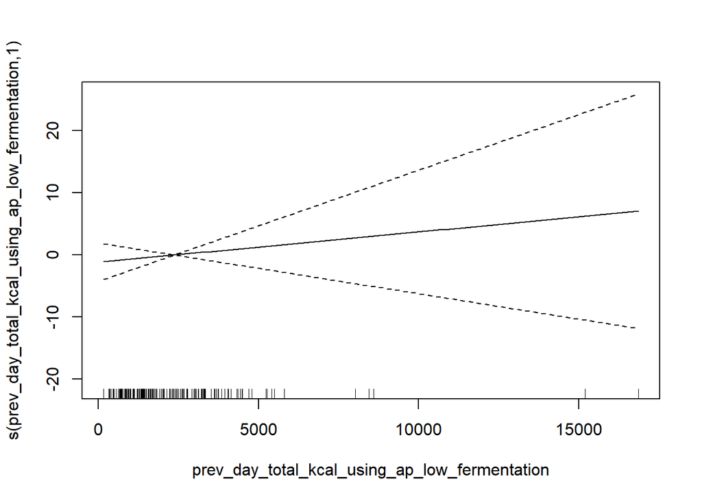

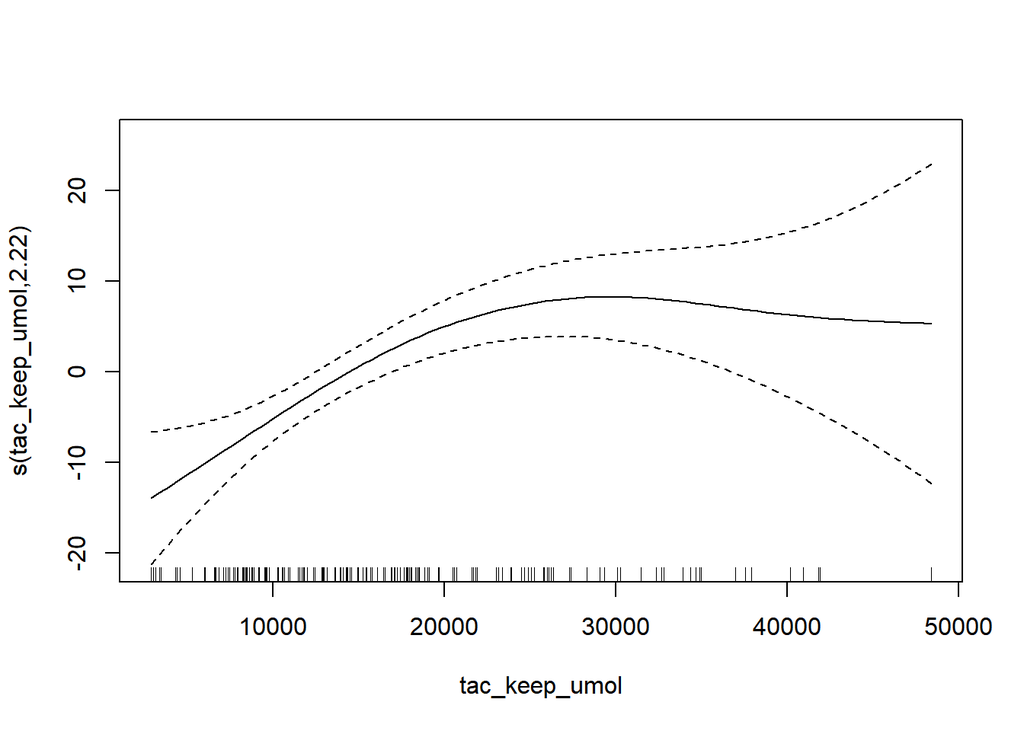

```
##
## Family: gaussian
## Link function: identity
##
## Formula:
## neop_keep ~ s(prev_day_total_kcal_using_ap_low_fermentation)
##
## Parametric coefficients:
##             Estimate Std. Error t value Pr(>|t|)
## (Intercept)    669.2       35.5   18.85   <2e-16 ***
## ---
## Signif. codes:  0 '***' 0.001 '**' 0.01 '*' 0.05 '.' 0.1 ' ' 1
##
## Approximate significance of smooth terms:
##                                                  edf Ref.df     F  p-value
## s(prev_day_total_kcal_using_ap_low_fermentation) 7.5    7.5 5.406 2.59e-06 ***
## ---
## Signif. codes:  0 '***' 0.001 '**' 0.01 '*' 0.05 '.' 0.1 ' ' 1
##
## R-sq.(adj) =    0.1
##   Scale est. = 4.3381e+05  n = 448
```

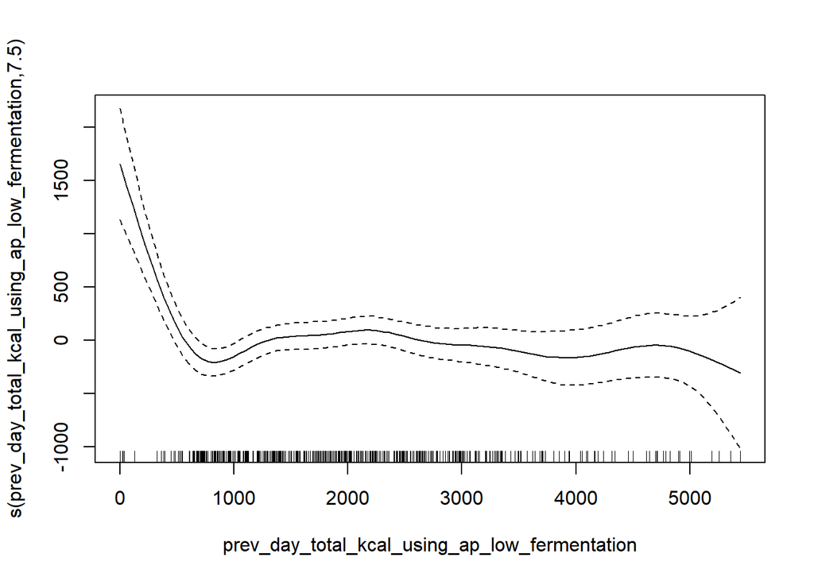

```
##
## Family: gaussian
## Link function: identity
##
## Formula:
## tac_keep ~ s(neop_keep)
##
## Parametric coefficients:
##             Estimate Std. Error t value Pr(>|t|)
## (Intercept)   7.2425     0.4456   16.25   <2e-16 ***
## ---
## Signif. codes:  0 '***' 0.001 '**' 0.01 '*' 0.05 '.' 0.1 ' ' 1
##
## Approximate significance of smooth terms:
##              edf Ref.df     F p-value
## s(neop_keep)   1      1 0.844   0.359
##
## R-sq.(adj) =  -0.00653
##   Scale est. = 18.122    n = 212
```

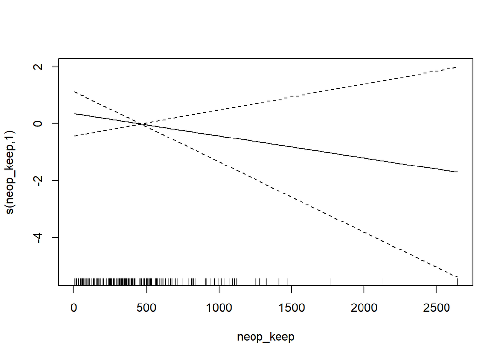

```
##
## Family: gaussian
## Link function: identity
##
## Formula:
## ohdg_keep ~ s(neop_keep)
##
## Parametric coefficients:
##             Estimate Std. Error t value Pr(>|t|)
## (Intercept)   20.066      0.845   23.75   <2e-16 ***
## ---
## Signif. codes:  0 '***' 0.001 '**' 0.01 '*' 0.05 '.' 0.1 ' ' 1
##
## Approximate significance of smooth terms:
##                edf Ref.df     F p-value
## s(neop_keep) 5.181  5.181 42.14  <2e-16 ***
## ---
## Signif. codes:  0 '***' 0.001 '**' 0.01 '*' 0.05 '.' 0.1 ' ' 1
##
## R-sq.(adj) =  0.363
##   Scale est. = 147.27    n = 377
```

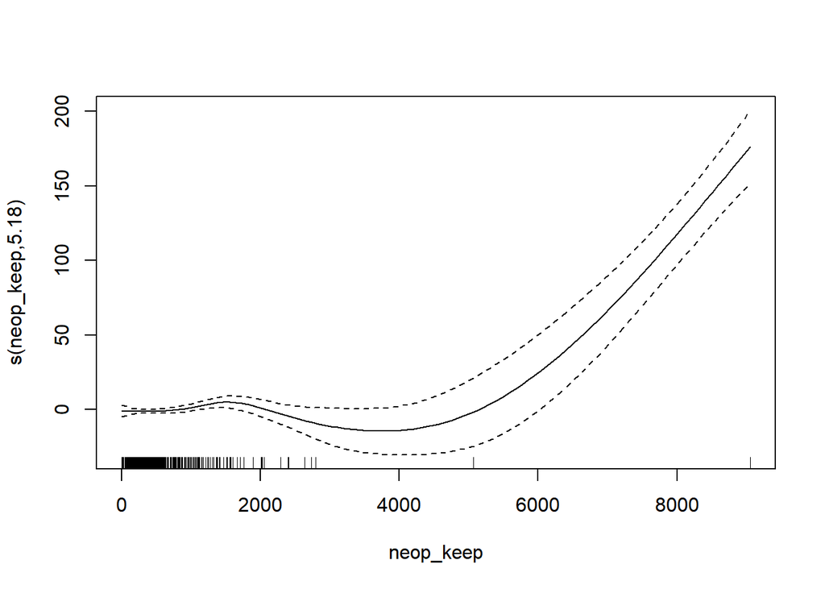

```
##
## Family: gaussian
## Link function: identity
##
## Formula:
## ohdg_keep ~ s(fai) + s(tac_keep_umol)
##
## Parametric coefficients:
##             Estimate Std. Error t value Pr(>|t|)
## (Intercept)  23.6381     0.9741   24.27   <2e-16 ***
## ---
## Signif. codes:  0 '***' 0.001 '**' 0.01 '*' 0.05 '.' 0.1 ' ' 1
##
## Approximate significance of smooth terms:
##                    edf Ref.df      F  p-value
## s(fai)           8.366  8.366  6.927  < 2e-16 ***
## s(tac_keep_umol) 1.000  1.000 21.144 7.84e-06 ***
## ---
## Signif. codes:  0 '***' 0.001 '**' 0.01 '*' 0.05 '.' 0.1 ' ' 1
##
## R-sq.(adj) =  0.322
##   Scale est. = 207.82    n = 220
```

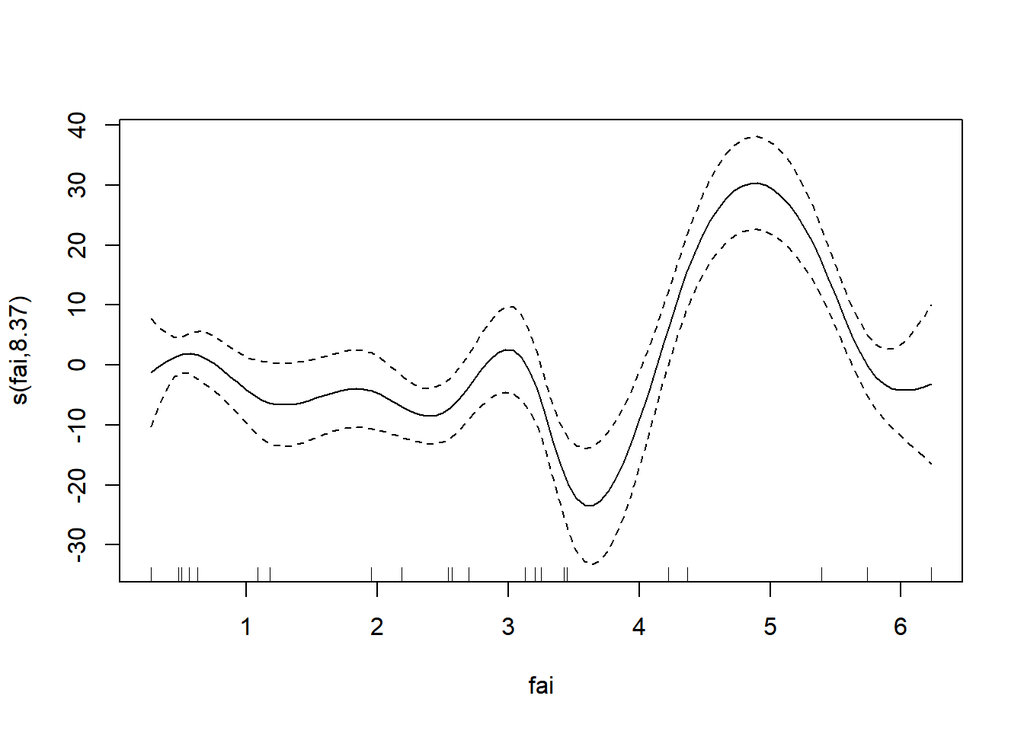

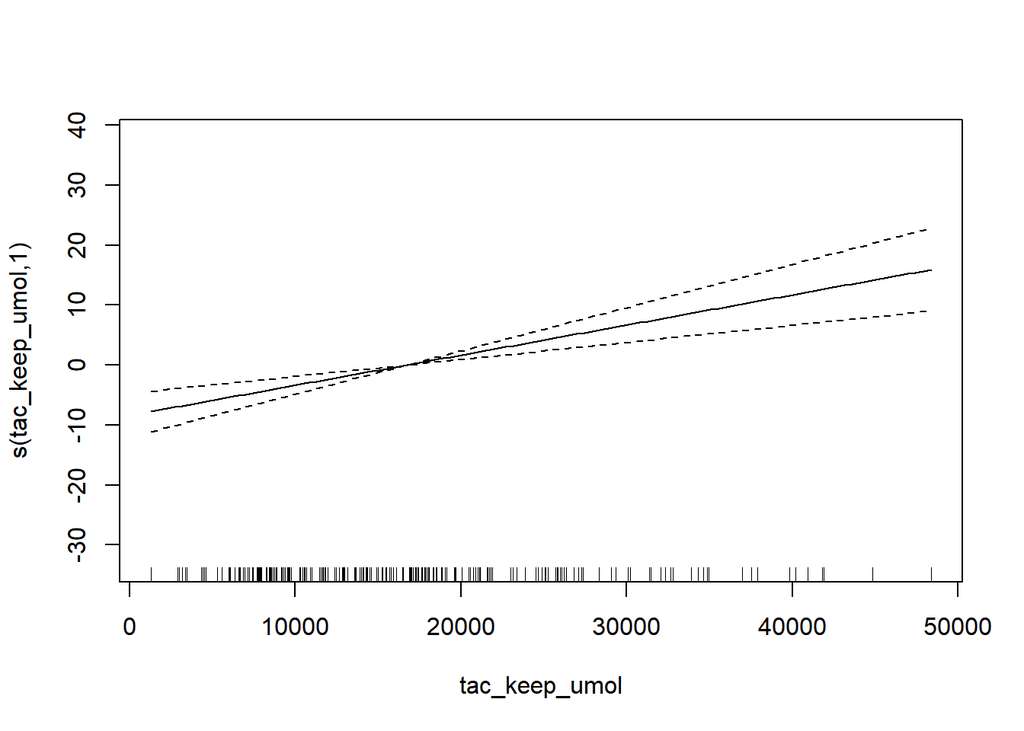